# Examen de Laboratorio Mayo 2018

```python
from __future__ import division
import numpy as np
import matplotlib.pyplot as plt
import scipy.optimize as op
%matplotlib inline
```

## Ejercicio 1

Escribir una función que calcule todas las raíces reales de una función $f$ en un intervalo $[a,b]$ y que utiliza el método de Bisección para calcular cada una de las raíces. Los **argumentos de entrada** serán la función **`f`** y los extremos del intervalo **`a`** y **`b`**. El **argumento de salida** será una lista que contenga todas las raíces. Se utilizará como criterio de parada del método de Bisección que la diferencia en valor absoluto entre dos iteraciones consecutivas sea menor que $10^{-12}$. Supondremos que todas las raíces de la función son de primer orden y están separadas, dos a dos, al menos $0.05$.

a) Usando argumentos de entrada adecuados, es decir, utilizando como argumento de entrada un intervalo adecuado que contenga **todas** las raíces de la función, utilizar dicha función para calcular todas las raíces reales de

$$x^4 + 2x^3 - 7x^2 + 3=0$$

y dibujar sobre la curva las raíces como puntos rojos.

b) Utilizar la misma función (sin modificaciones en su código) para calcular todas las raíces reales de

$$6x^6 + 5x^5 - 14x^4 + x^3 + 2x^2 - 0.05=0$$

y dibujar sobre la curva las raíces como puntos rojos.

NOTA: Tener en cuenta que un polinomio de grado $n$ tiene como máximo $n$ raíces reales y, si $n$ es par, tiene un número par de raíces reales.

```python
def biseccion(f,aa,bb):
    # Solo aplica bisección si se cumplen las condiciones necesarias
    if f(aa)*f(bb) < 0:
        cond = True
        while cond == True:
            m = (aa+bb)/2.
            if f(aa)*f(m) < 0:
                bb = m
            elif f(m)*f(bb) < 0:
                aa = m
            else:
                return (True,m)
            cond = abs(bb-aa)/2. > 1.e-12
        return (True,m)
    # En caso contrario devuelve un False
    else:
        return (False,a)
```

```python
def raices(f,a,b):
    '''
    - Dividimos [a,b] en intervalos de longitud dx
    y los enviamos a la función bisección
    si no se cumplen las condiciones para aplicar bisección
    no hace nada y pasa al intervalo siguiente.

    - Caso contrario la función la función almacena
    la solución obtenida por bisección
    '''
    sol = []
    dx = 0.05
    valores = np.arange(a,b,dx)

    for aa in valores:
        bb = aa + dx
        sal = biseccion(f,aa,bb)
        if sal[0] == True:
            sol.append(sal[1])
    return sol
```

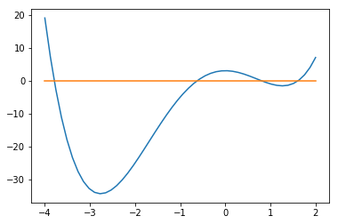

```python
f1 = lambda x: x**4 + 2*x**3 - 7*x**2 + 3
f2 = lambda x: 6*x**6 + 5*x**5 - 14*x**4 + x**3 + 2*x**2 - 0.05

a = -4.
b = 2.
x = np.linspace(a,b)
plt.plot(x,f1(x),x,x*0)
plt.show()
```

```python
r1 = raices(f1,a,b)
print (r1)
```

```
[-3.791287847478816, -0.6180339887490965, 0.7912878474787991, 1.6180339887490645]
```

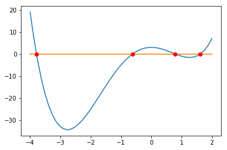

```python
plt.plot(x,f1(x),x,x*0)
n1 = len(r1)
plt.plot(r1,np.zeros((n1,)),'ro')
plt.show()
```

```python
print(op.newton(f1,-4.))
print(op.newton(f1,-1.))
print(op.newton(f1,0.5))
print(op.newton(f1,2.))
```

```
-3.79128784747792
-0.6180339887499672
0.7912878474779201
1.6180339887498947
```

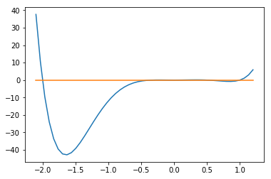

```python
a = -2.1
b = 1.2
x = np.linspace(a,b)
plt.plot(x,f2(x),x,x*0)
plt.show()
```

```python
r2 = raices(f2,a,b)
print (r2)
```

```
[-2.0001666018928526, -0.2578874026468905, -0.208835620868201, 0.1663667345259374, 0.463108219449341, 1.0040813380983198]
```

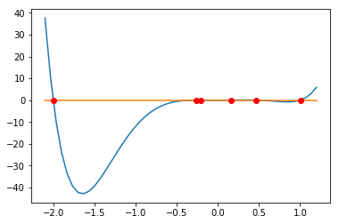

```python
plt.plot(x,f2(x),x,x*0)
n2 = len(r2)
plt.plot(r2,np.zeros((n2,)),'ro')
plt.show()
```

## Ejercicio 2

Usar el método de newton para encontrar el polinomio que pasa por los puntos. Dibujarlo.

Escribir un programa que use el método de Newton para calcular el polinomio de interpolación que pasa por los puntos siguientes. Dibujar el polinomio como una linea azul y los nodos por los que pasa con puntos rojos, añadiendo una leyenda explicativa.

$$ \begin{array}{|c|c|c|c|c|c|} \hline x & −3 & 2 & −1& 3 &1\\ \hline\hline y &0 & 5 & −4 & 12 & 0 \\\hline \end{array} $$

Los siguientes puntos pertenecen a un polinomio. Usando la tabla de diferencias divididas correspondientes, dar el grado del polinomio que pasa por dichos puntos. Dibujarlo junto con los nodos.

$$ \begin{array}{|c|c|c|c|c|c|} \hline x & −2& 1 &4 &−1&3 &−4\\ \hline\hline y &−1& 2& 59 &4 &24& −53 \\\hline \end{array} $$

```python
def dif_div(x,y):
    n = len(x)
    d = np.zeros((n,n))
    d[:,0] = y
    for j in range(1,n):
        for i in range(n-j):
            d[i,j] = d[i+1,j-1]-d[i,j-1]
            d[i,j] /= (x[i+j]-x[i])
    return d
```

```python
def newton_polinomio(z,x,y):
    n = len(x)
    d = dif_div(x,y)

    P = 0.
    factor = 1.
    for i in range(n):
        P += d[0,i]*factor
        factor *= (z-x[i])
    return P
```

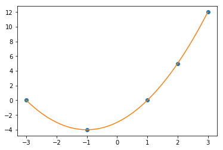

```python
x = [-3., 2., -1., 3., 1.]
y = [0., 5., -4., 12., 0.]

z = np.linspace(min(x),max(x))
P = newton_polinomio(z,x,y)

plt.plot(x,y,'o')
plt.plot(z,P)
plt.show()
```

```
[-1.  1.  3.  1.  0.  0.]
```

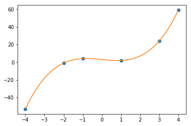

```python
x = [-2., 1., 4., -1., 3., -4.]
y = [-1., 2., 59., 4., 24., -53.]

s = dif_div(x,y)
print(s[0,:])

z = np.linspace(min(x),max(x))
P = newton_polinomio(z,x,y)

plt.plot(x,y,'o')
plt.plot(z,P)
plt.show()
```

Como los coeficientes de la parte del polinomio de grado 4 y 5 son cero, el polinomio es de grado tres.